# BIO-657 Final Project: Flowering Timing & Competition

Tanner Lyons

2026-05-04

# Project Overview

**Experimental Backround** The dataset that I chose is from the study by Kehrberger & Holzschuh (2019), which looked at how the timing of flowering influences pollinator interactions and reproductive success in the plant Primrose (*Primula vulgaris*). The phenology can have a strong impact on plant reproduction because flowering timing determines pollinator availability and competition. The primary goal of this study was to determine how flowering abundance, pollinator visitation rates, and environmental factors vary throughout a flowering season, and then how these factors are related to reproductive success. Data was collected across the 2015 flowering season for *P. vulgaris*. Site-level data was recorded daily and weekly to track flower abundance, pollinator activity, and environmental conditions. Individual flowers were also monitored for bud opening, pollination, and reproductive success. Two experimental treatments were also done, controlling pollination limitation and means of pollination.

Kehrberger, S., & Holzschuh, A. (2019). How does timing of flowering affect competition for pollinators, flower visitation and seed set in an early spring grassland plant? *Scientific Reports, 9*(1), 15593. https://doi.org/10.1038/s41598-019-51916-0

# Project Workflow

## Setup

Load the .xlsx file containing the dataset.

- The readxl package pulls specific pages from our 5-page datasheet.

```r
file <- "Kehrberger_Scientific_Reports.xlsx"
```

Convert every sheet to a separate data frame.

- Clean column names using the janitor package’s clean_names()
- Manually rename leftover names for clarity using dplyr’s rename()

```r
T1 <- read_excel(file, sheet = "T1") %>%
  as_tibble() %>%
  janitor::clean_names() %>%
  rename(
    j_day = julian_date_of_year_2015,
    flower_count = number_of_p_vulgaris_flowers,
    visitation_rate = day_specific_flower_visitation_rate_individuals_per_hour,
    competitor_count = day_specific_number_of_other_than_p_vulgaris_flowering_plant_species,
    temperature = temperature_c
  )

T2 <- read_excel(file, sheet = "T2") %>%
  as_tibble() %>%
  janitor::clean_names() %>%
  rename(
    week = week_of_the_year_2015,
    flower_count = number_of_p_vulgaris_flowers,
    bee_abundance = mean_bee_abundance,
    visitation_rate = mean_bee_visitation_rate_on_p_vulgaris_flowers,
    competitor_count = total_number_of_other_flowering_plant_species
  )

T3 <- read_excel(file, sheet = "T3") %>%
  as_tibble() %>%
  janitor::clean_names() %>%
  rename(
    j_open = julian_date_of_bud_opening,
    longevitiy = floral_longevity_days,
    pollinator_hours = flower_specific_number_of_pollinator_suitable_hours,
    seed_set = seed_set_percent,
    mean_temp = flower_specific_mean_temperature_c,
    bee_visits = estimated_total_number_of_bee_visits_per_flower_of_p_vulgaris
  )

T4 <- read_excel(file, sheet = "T4") %>%
  as_tibble() %>%
  janitor::clean_names() %>%
  rename(
    j_open = julian_date_of_bud_opening,
    seed_set = seed_set_percent
  )

T5 <- read_excel(file, sheet = "T5") %>%
  as_tibble() %>%
  janitor::clean_names() %>%
  rename(
    j_open = julian_date_of_bud_opening,
    seed_set = seed_set_percent
  )
```

Correct Object Formats using dplyr’s mutate().

- Convert Julian dates to Date objects using lubridate’s as.Date().
  - if j_day = 1, date should = 2015-01-01
- Factorize categorical variables.
- Fix incorrectly assigned numerical values (N/As as characters).

```r
T1 <- T1 %>%
  mutate(date = as.Date(j_day - 1, origin = "2015-01-01"),
         site = as.factor(site),
         visitation_rate = as.numeric(visitation_rate),
         temperature = as.numeric(temperature)
         )

T2 <- T2 %>%
  mutate(site = as.factor(site),
         bee_abundance = as.numeric(bee_abundance),
         visitation_rate = as.numeric(visitation_rate),
         competitor_count = as.numeric(competitor_count)
         )

T3 <- T3 %>%
  mutate(date_open = as.Date(j_open - 1 , origin = "2015-01-01"),
         site = as.factor(site),
         flower_id = as.factor(flower_id)
         )

T4 <- T4 %>%
  mutate(date_open = as.Date(j_open - 1, origin = "2015-01-01"),
         site = as.factor(site),
         pollen_limitation = as.numeric(pollen_limitation)
         )

T5 <- T5 %>%
  mutate(date_open = as.Date(j_open - 1, origin = "2015-01-01"),
         site = as.factor(site),
         treatment = as.factor(treatment)
         )
```

T4 has a really nasty outlier that’ll interfere with our statistics, lets remove it!

```r
Q1 <- quantile(T4$pollen_limitation, 0.25, na.rm = T)
Q3 <- quantile(T4$pollen_limitation, 0.75, na.rm = T)
IQR <- Q3 - Q1

T4 <- T4 %>%
  filter(pollen_limitation >= (Q1 - 1.5 * IQR) & pollen_limitation <= (Q3 + 1.5 * IQR)
         )
```

Verify that the data structure is correct for all dataframes before proceeding.

```r
glimpse(c(T1, T2, T3, T4, T5))
```

```
## List of 32
##  $ site             : Factor w/ 8 levels "1","2","3","4",..: 1 1 1 1 1 1 1 1 1 1 ...
##  $ j_day            : num [1:192] 72 77 79 82 84 86 89 91 93 96 ...
##  $ flower_count     : num [1:192] 0 22 50 102 220 ...
##  $ visitation_rate  : num [1:192] NA 0.3836 0 0 0.0182 ...
##  $ competitor_count : num [1:192] 0 0 0 0 0 0 0 0 1 1 ...
##  $ temperature      : num [1:192] NA 17.9 17.7 7.1 22 NA NA 6.8 7.9 11.7 ...
##  $ date             : Date[1:192], format: "2015-03-13" "2015-03-18" ...
##  $ site             : Factor w/ 8 levels "1","2","3","4",..: 1 1 1 1 1 1 1 1 1 1 ...
##  $ week             : num [1:80] 11 12 13 14 15 16 17 18 19 20 ...
##  $ flower_count     : num [1:80] 0 36 161.6 164.2 82.2 ...
##  $ bee_abundance    : num [1:80] NA 14.63 5 2.89 19.67 ...
##  $ visitation_rate  : num [1:80] NA 0.19179 0.00911 0.00893 0.03251 ...
##  $ competitor_count : num [1:80] NA 0 0 1 2 4 4 6 6 NA ...
##  $ site             : Factor w/ 8 levels "1","2","3","4",..: 1 1 1 1 1 1 1 1 1 1 ...
```

[output cut: 18 more lines]

## Data Transformation

Summarize statistics across sites using dplyr’s summarize().

```r
T1_site_summary <- T1 %>%
  group_by(site) %>%
  summarize(
    mean_flowers = mean(flower_count, na.rm = TRUE),
    mean_visitation = mean(visitation_rate, na.rm = TRUE),
    mean_temp = mean(temperature, na.rm = TRUE),
    total_competitors = sum(competitor_count, na.rm = TRUE)
  ) %>%
  ungroup()

T2_site_summary <- T2 %>%
  group_by(site) %>%
  summarize(
    mean_flowers = mean(flower_count, na.rm = T),
    mean_bees = mean(bee_abundance, na.rm = T),
    mean_visitation = mean(visitation_rate, na.rm = T)
    ) %>%
  ungroup()

T3_site_summary <- T3 %>%
  group_by(site) %>%
  summarize(
    mean_longevity = mean(longevitiy, na.rm = T),
    mean_pollinator_hours = mean(pollinator_hours, na.rm = T),
    mean_seed_set = mean(seed_set, na.rm = T)
  ) %>%
  ungroup()

T4_site_summary <- T4 %>%
  group_by(site) %>%
  summarize(
    mean_pollen_limitation <- mean(pollen_limitation, na.rm = T),
    mean_seed_set = mean(seed_set, na.rm = T)
  ) %>%
  ungroup()

T5_site_summary <- T5 %>%
  group_by(site,treatment) %>%
  summarize(
    mean_open_date = mean(j_open, na.rm = T),
    mean_seed_set = mean(seed_set, na.rm = T)
  ) %>%
  ungroup()
```

Summarize statistics across dates using dplyr’s summarize().

```r
T1_date_summary <- T1 %>%
  group_by(date) %>%
  summarize(
    mean_flowers = mean(flower_count, na.rm = TRUE),
    mean_visitation = mean(visitation_rate, na.rm = TRUE),
    mean_temp = mean(temperature, na.rm = TRUE),
    total_competitors = sum(competitor_count, na.rm = TRUE)
  ) %>%
  ungroup()

T2_date_summary <- T2 %>%
  group_by(week) %>%
  summarize(
    mean_flowers = mean(flower_count, na.rm = T),
    mean_bees = mean(bee_abundance, na.rm = T),
    mean_visitation = mean(visitation_rate, na.rm = T)
    ) %>%
  ungroup()
```

## Visualization

Visualize flowering abundance over time using gganimate.

- Color by site.
- Reveal the graph by date (x-axis).

[figure not shown]

```r
(plot_T1_time <- T1 %>%
   ggplot(aes(x = date,
              y = flower_count,
              color = site,
              group = site)) +
   geom_line(alpha = 0.9) +
   theme_bw() +
   labs(title = "Flowering Abundance over Time",
        x = "Date",
        y = "Flower Count",
        color = "Site") +
   transition_reveal(date)
 )
```

Visualize the relationship between flower abundance and bee visitation.

- Color by site.
- Apply log+1 scaling to visitation_rate.
  - These values are too small to accurately visualize trends.

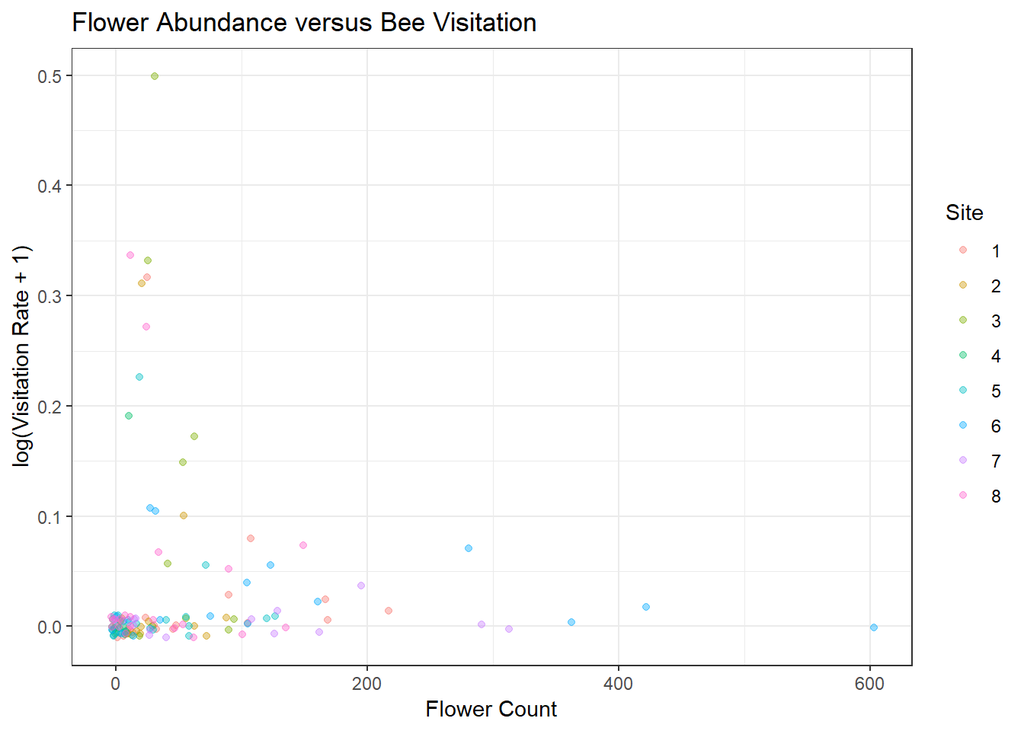

```r
(plot_T1_visitation <- T1 %>%
    ggplot(aes(x = flower_count,
               y = log1p(visitation_rate),
               color = site)) +
    geom_jitter(alpha = 0.4, height = 0.01, width = 5) +
    theme_bw() +
    labs(title = "Flower Abundance versus Bee Visitation",
         x = "Flower Count",
         y = "log(Visitation Rate + 1)",
         color = "Site")
  )
```

**Figure 2.** Flower count and bee visitation rate appear to have a negative relationship, when only looking at values that aren’t highly clustered due to extremely small visitation rates. This relationship appears very weak, though.

Visualize bee abundance over time across each site.

- Color by site.
- Apply bin scaling to the x-axis to make weeks discrete.

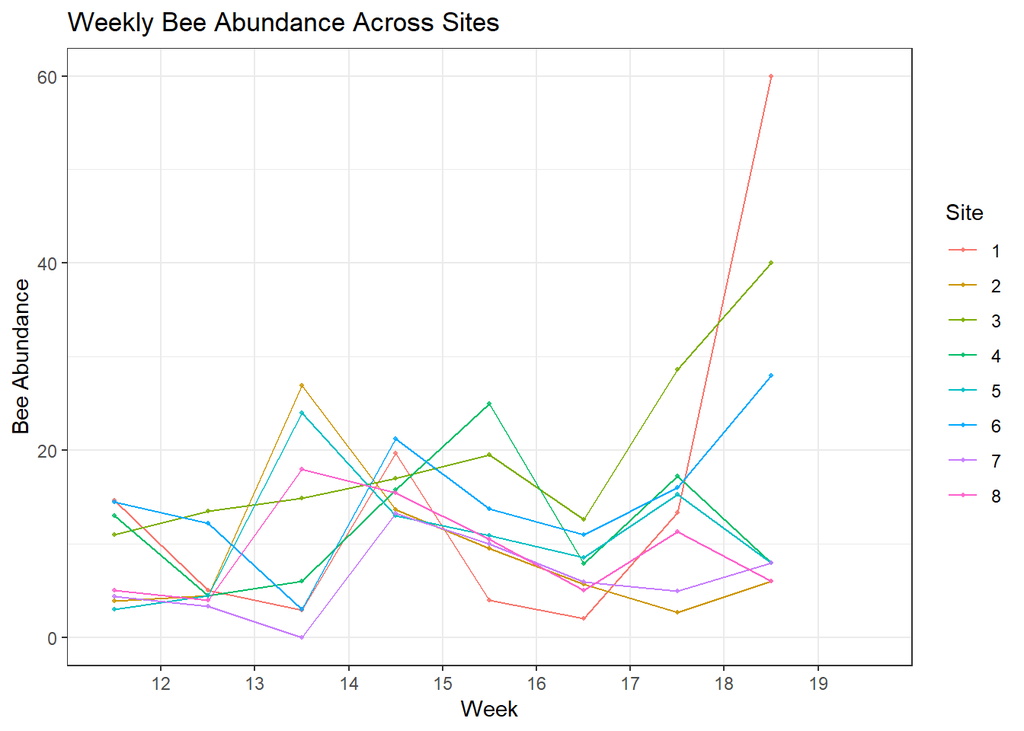

```r
(plot_T2 <- T2 %>%
    ggplot(aes(x = week,
               y = bee_abundance,
               color = site)) +
    geom_line() +
    geom_point(size = 0.8, alpha = 0.8) +
    theme_bw() +
    scale_x_binned(expand = c(0, 0)) +
    labs(title = "Weekly Bee Abundance Across Sites",
         x = "Week",
         y  = "Bee Abundance",
         color = "Site")
  )
```

**Figure 3.** Bee abundance fluctuates weekly across most sites, with a distinctly elevated amounts between weeks 13 through 16, which aligns with the flowering period of *Primula vulgaris*. Site’s 1 and 3 also experienced heavy peaks around week 18, which is likely attributed to other flowering species. These other species are accounted for in this dataset, but not this manipulation.

Visualize the relationship between Bee Visitation and Seed Set %.

- Color by site.
- Smooth trends using a linear model.

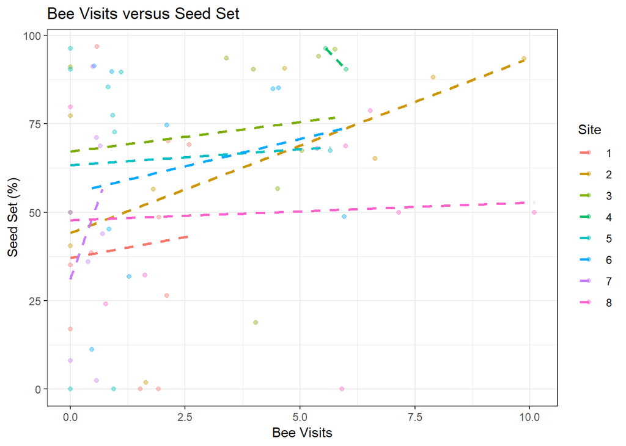

```r
(plot_T3 <- T3 %>%
    ggplot(aes(x = bee_visits,
               y = seed_set,
               color = site)) +
    geom_point(alpha = 0.4) +
    geom_smooth(method = "lm", se = F, linetype = "dashed") +
    theme_bw() +
    labs(title = "Bee Visits versus Seed Set",
         x = "Bee Visits",
         y = "Seed Set (%)",
         color = "Site")
  )
```

**Figure 4.** Bee visitation is loosely positively related with seed set across most sites and negatively at site 4, which has fewer observations. The positive relationship is expetced, as these flowers rely on insect pollination to produce seeds. Several individuals have high seed set but low bee visitation, which is likely explained by non-bee pollinators or bees that were not observed (observer bias).

Visualize the relationship between Pollen Limitation and Seed Set %.

- Smooth trends using a linear model.
- Add the equation and p-value of the lm using ggpmisc’s stat_poly_eq().

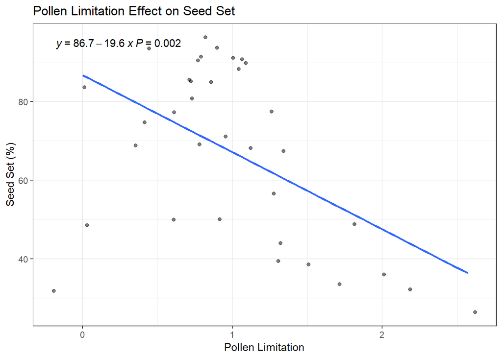

```r
(plot_T4 <- T4 %>%
    ggplot(aes(x = pollen_limitation,
               y = seed_set)) +
    geom_jitter(alpha = 0.5, width = 0.2) +
    geom_smooth(method = "lm", se = F) +
    theme_bw() +
    labs(title = "Pollen Limitation Effect on Seed Set",
         x = "Pollen Limitation",
         y = "Seed Set (%)") +
    stat_poly_eq(aes(label = paste(..eq.label..,
                                   ..p.value.label..,
                                   sep = "~")))
)
```

**Figure 5.** As the rate of pollen limitation increases, the percentage seed set significantly decreases at 19.6% per unit (**, p = 0.002).

Visualize the results of each pollination treatment on Seed Set %.

- Add p-values using ggpubr’s stat_compare_means().

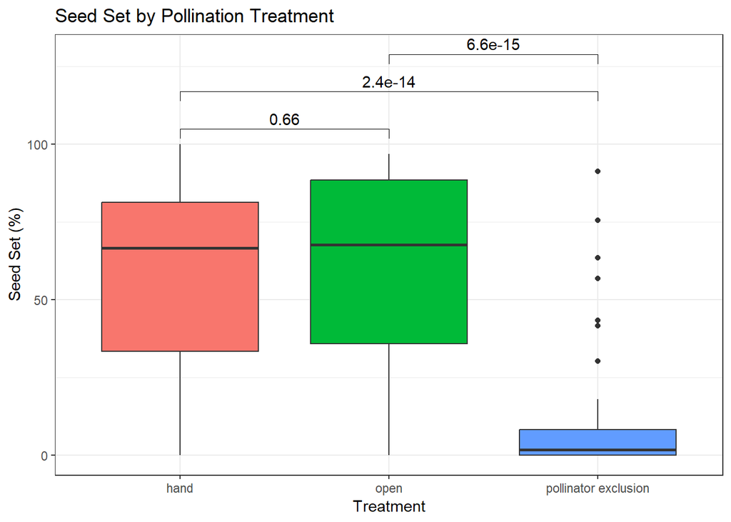

```r
(plot_T5 <- T5 %>%
    ggplot(aes(x = treatment,
               y = seed_set,
               fill = treatment)) +
    geom_boxplot() +
    theme_bw() +
    labs(title = "Seed Set by Pollination Treatment",
         x = "Treatment",
         y = "Seed Set (%)") +
    theme(legend.position = "none") +
    stat_compare_means(method = "t.test",
                       label = "p.format",
                       comparisons = list(
                         c("hand", "open"),
                         c("hand", "pollinator exclusion"),
                         c("open", "pollinator exclusion")
                       ))
  )
```

## Export Results

Export summary statistics dataframes as .csv files.

```r
write_csv(T1_date_summary, "T1_date_summary.csv")
write_csv(T1_site_summary, "T1_site_summary.csv")
write_csv(T2_date_summary, "T2_date_summary.csv")
write_csv(T2_site_summary, "T2_site_summary.csv")
write_csv(T3_site_summary, "T3_site_summary.csv")
write_csv(T4_site_summary, "T4_site_summary.csv")
write_csv(T5_site_summary, "T5_site_summary.csv")
```

Export figures as .png and .gif files.

```r
# anim_save("T1_FlowerAbundance.gif", plot_T1_time, width = 1600, height = 1000)
ggsave("T1_VisitationRate.png", plot_T1_visitation, height = 5, width = 8)
ggsave("T2_BeeAbundance.png", plot_T2, height = 5, width = 8)
ggsave("T3_BeePollination.png", plot_T3, height = 5, width = 8)
ggsave("T4_PollenLimitation.png", plot_T4, height = 5, width = 8)
ggsave("T5_PollinationTreatment.png", plot_T5, height = 5, width = 8)
```